# Analysis of employer expectancies with BayesMallows

Christoph Krausser

1/14/2022

First, we do a test run to check convergence of the MCMC algorithm, and then get trace plots with assess_convergence.

```r
require(BayesMallows)

mat.ranking.bm_test <- compute_mallows(mat.ranking)
```

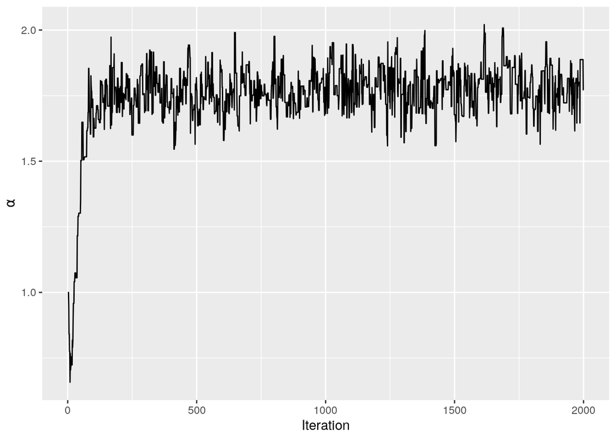

```r
assess_convergence(mat.ranking.bm_test)
```

The algorithm seems to be mixing well after around 150 iterations.

Next, we study the convergence of ρ. To avoid overly complex plots, we plot the first 5 criteria only, by specifying this in the items argument.

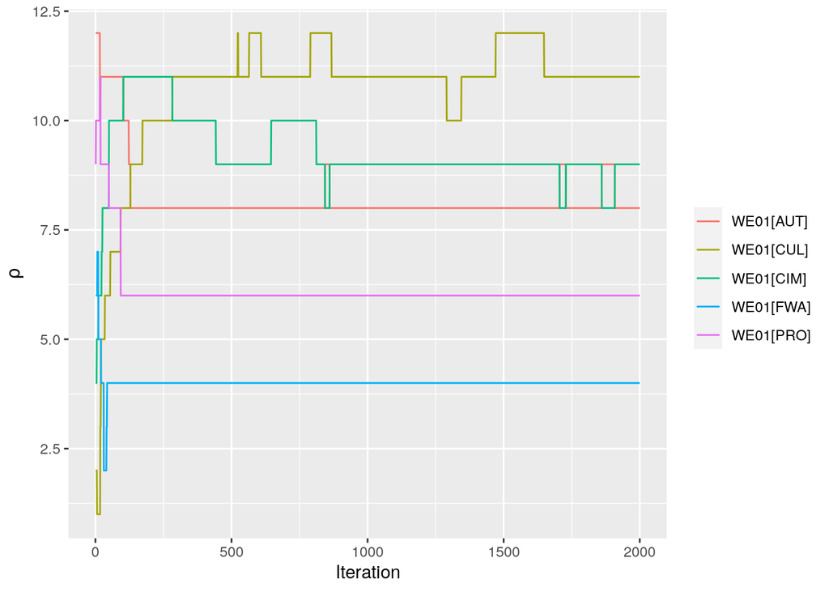

```r
assess_convergence(mat.ranking.bm_test, parameter = "rho", items = 1:5)
```

From the trace plots, we decide to discard the first 1,000 MCMC samples as burn-in. We rerun the algorithm to get 500,000 samples after burn-in. The object bmm_visual has S3 class “BayesMallows”, so we plot the posterior distribution of a with plot.BayesMallows.

```r
burn_in <- 1000
nmc <- 500000

mat.ranking.bm_visual <- compute_mallows(mat.ranking, nmc = (nmc+burn_in), verbose = TRUE)
mat.ranking.bm_visual$burnin <- burn_in # Set burn-in
```

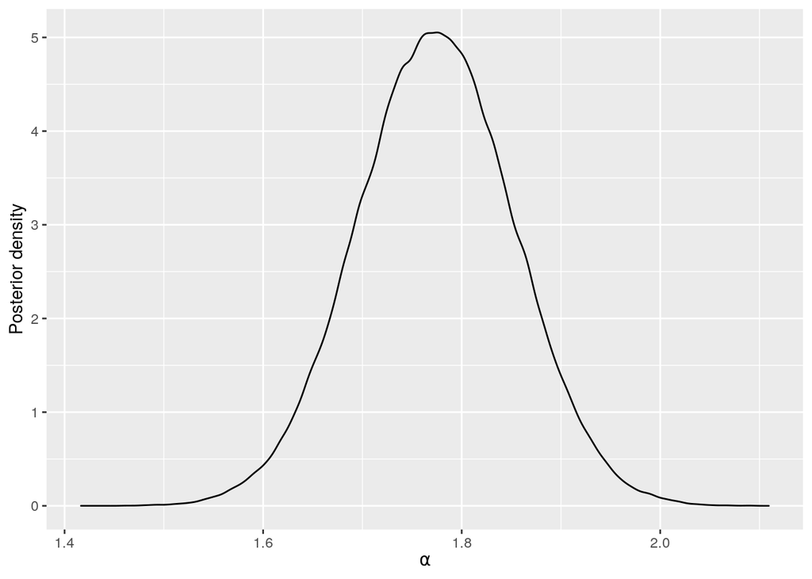

```r
plot(mat.ranking.bm_visual)
```

The posterior mass is symmetrically centered between 1.6 and 2.0, with a mean around 1.8.

We can also get posterior credible intervals for α using compute_posterior_intervals, which returns both highest posterior density intervals (HPDI) and central intervals:

```r
compute_posterior_intervals(mat.ranking.bm_visual, decimals = 1L)
```

```
## # A tibble: 1 × 6
##   parameter  mean median conf_level hpdi      central_interval
##   <chr>     <dbl>  <dbl> <chr>      <chr>     <chr>
## 1 alpha       1.8    1.8 95 %       [1.6,1.9] [1.6,1.9]
```

Next, we can go on to study the posterior distribution of ρ. To show all criteria, we explicitly set items = 1:12:

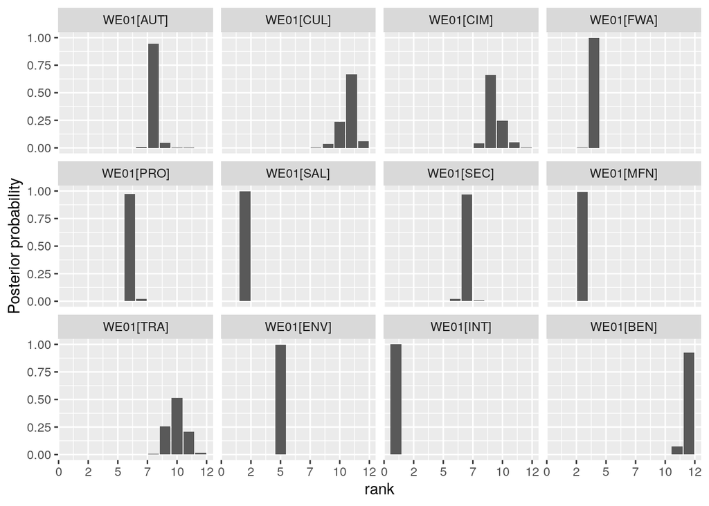

```r
plot(mat.ranking.bm_visual, parameter = "rho", items = 1:12)
```

Most criteria such as flexible work arrangements, salery, work environment or working on interesting tasks have highly peaked posterior distributions, indicating low uncertainty about their ranking.